# IFS - Data Science - Alex Paulo

### Dataset from https://www.kaggle.com/datasets/vikrishnan/boston-house-prices

### O que é Regressão?

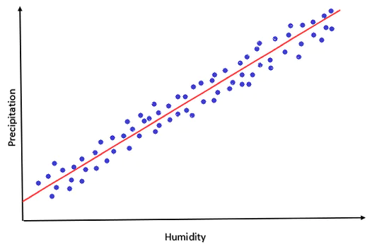

```python
from IPython.display import display, Image

display(Image(filename='./humidity_precipitation.png'))
```

Por meio de um gráfico de dispersão (scatter) é possível perceber a inquestionável relação entre humidade e precipitação! Ambientes com maior umidade relativa (referenciada como umidade atmosférica) apresentam maior precipitação! Como uma sauna. Maior humidade (ambientes próximos a rios e ao mar) significa menor amplitude térmica! Por isso, no deserto, é possível mensurar 0 graus à noite... e 50 graus durante o dia!

| Aluno | Horas de Estudo | Nota |
| --- | --- | --- |
| José | 20 | 9,5 |
| Maria | 12 | 2,5 |
| Pedro | 14 | 3,6 |
| Marcelo | 15 | 6,7 |
| Roberto | 15 | 5,2 |
| Marta | 9 | 1 |
| Ricardo | 5 | 0 |
| Kaio | 4 | 1,5 |
| Renato | 8 | 2 |
| Francisco | 13 | 3 |
| Vagner | 14 | 3,5 |
| Henrique | 15 | 4,5 |
| Vania | 19 | 8,5 |
| Camila | 18 | 7,5 |
| Priscila | 12 | 5 |
| Jorge | 11 | 4 |
| Rafael | 10 | 3 |
| Rodrigo | 15 | 5 |
| Lucas | 17 | 6,5 |
| Bruno | 20 | 10 |

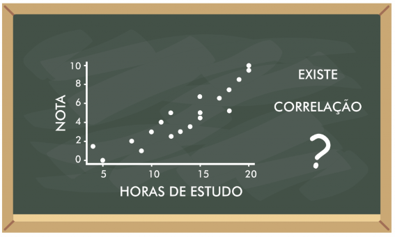

```python
display(Image(filename='./nota_x_horas_estudo.png'))
```

### Exercício

##### 1) Importe os dados da base gratuita existente em https://www.kaggle.com/datasets/vikrishnan/boston-house-prices. Baixe o arquivo, estude seu formato, e organize um csv que deverá ser importado utilizando o método read_csv da biblioteca pandas.

##### 2) Faça uma análise exploratória dos dados carregados no DataFrame adquirido com a invocação do método read_csv, realizada na questão anterior.

##### 3) Faça um split nos dados do DataFrame, com o objetivo de alocar o campo que a regressão almeja representar "MEDV" (Valor de Mercado) em uma variável intitulada y. E o campo que deverá ser utilizado como subsídio para a regressão "RM" (Média de quartos por habilitação) em uma variável intitulada X.

##### 4) Monte um gráfico para estudar a hipótese de correlação entre as variáveis MEDV e RM.

##### 5) Se a correlação for perceptível*, utilize a classe LinearRegression, do pacote sklearn.linear_model, para configurar uma regressão que seja útil para mensurar um estimativa de preço proveniente da correlação identificada.

*: Existem coeficientes de correlação na estatística, para mensurar tais correlações. Sobretudo, neste exercício específico, tente inferir a correlação por meio do gráfico utilizado como resposta para a questão 4.

##### 6) Acrescente, ao gráfico criado na quetão 4, uma linha representando a mensuração de valor em função da média de número de quartos.

### EDA (Exploratory Data Analyse)

```python
# Import necessary modules
import pandas as pd

boston = pd.read_csv('housing.csv')

print(boston.dtypes)
print('---------')
print(boston.head())
```

```
CRIM       float64
ZN         float64
INDUS      float64
CHAS         int64
NOX        float64
RM         float64
AGE        float64
DIS        float64
RAD          int64
TAX        float64
PTRATIO    float64
B          float64
LSTAT      float64
MEDV       float64
dtype: object
---------
      CRIM    ZN  INDUS  CHAS    NOX     RM   AGE     DIS  RAD    TAX  \
0  0.00632  18.0   2.31     0  0.538  6.575  65.2  4.0900    1  296.0
1  0.02731   0.0   7.07     0  0.469  6.421  78.9  4.9671    2  242.0
2  0.02729   0.0   7.07     0  0.469  7.185  61.1  4.9671    2  242.0
3  0.03237   0.0   2.18     0  0.458  6.998  45.8  6.0622    3  222.0
4  0.06905   0.0   2.18     0  0.458  7.147  54.2  6.0622    3  222.0

   PTRATIO       B  LSTAT  MEDV
0     15.3  396.90   4.98  24.0
1     17.8  396.90   9.14  21.6
2     17.8  392.83   4.03  34.7
3     18.7  394.63   2.94  33.4
4     18.7  396.90   5.33  36.2
```

### Organizing features and target arrays

```python
X = boston.drop('MEDV', axis=1).values
y = boston['MEDV'].values

# To predict price from a single feature... lets get "RM: average number of rooms per dwelling"
X_rooms = X[:,5]

y = y.reshape(-1, 1)
X_rooms = X_rooms.reshape(-1, 1)
```

### Studying correlation between RM and MEDV

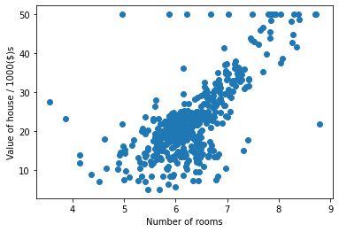

```python
import matplotlib.pyplot as plt
plt.scatter(X_rooms, y)
plt.ylabel('Value of house / 1000($)s')
plt.xlabel('Number of rooms')

plt.show()
```

### Fitting a Regression Model

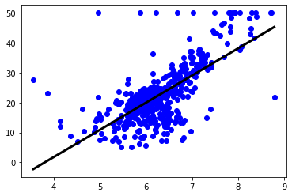

```python
import numpy as np
from sklearn.linear_model import LinearRegression

reg = LinearRegression()

reg.fit(X_rooms, y)
prediction_space = np.linspace( min(X_rooms), max(X_rooms) ).reshape(-1, 1)

plt.scatter( X_rooms, y, color='blue' )
plt.plot( prediction_space, reg.predict(prediction_space), color='black', linewidth=3 )

plt.show()
```